# Hipposideros.rad.filtering

Devon DeRaad

5/3/2022

# SNPfiltR quality filtering pipeline

### Read in your unfiltered vcf file

```r
library(vcfR)
```

```r
library(ggplot2)
library(gridExtra)
library(ggridges)
library(adegenet)
library(SNPfiltR)
library(dplyr)
#read in vcf as vcfR
vcfR <- read.vcfR("~/Desktop/hipposideros/n3.vcf")
### check the metadata present in your vcf
vcfR
vcfR@fix[1:10,1:8]
vcfR@gt[1:10,1:2]

#read in sample metadata
samps<-read.csv("~/Desktop/hipposideros/hipposideros.sampling.csv")
#retain samples that were sequenced successfully
samps<-samps[samps$id %in% colnames(vcfR@gt),]
#reorder sampling file to match order of samples in vcf
samps<-samps[match(colnames(vcfR@gt)[-1], samps$id),]
samps$id == colnames(vcfR@gt)[-1] #check that order matches

#generate popmap file. Two column popmap with the same format as stacks, and the columns must be named 'id' and 'pop'
popmap<-data.frame(id=samps$id,
                   pop=paste(samps$species, samps$Island, sep = "_"))
table(popmap$pop)
```

[output not shown]

## step 1: Implement quality filters that don’t involve missing data. This is because removing low data samples will alter percentage/quantile based missing data cutoffs, so we wait to implement those until after deciding on our final set of samples for downstream analysis

```r
#hard filter to minimum depth of 3, and minimum genotype quality of 30
vcfR<-hard_filter(vcfR, depth = 3, gq = 30)
```

```
## 0.02% of genotypes fall below a read depth of 3 and were converted to NA
```

```
## 8.31% of genotypes fall below a genotype quality of 30 and were converted to NA
```

### Use this function to filter for allele balance

### from Puritz SNP filtering tutorial “Allele balance: a number between 0 and 1 representing the ratio of reads showing the reference allele to all reads, considering only reads from individuals called as heterozygous, we expect that the allele balance in our data (for real loci) should be close to 0.5”

```r
#execute allele balance filter
vcfR<-filter_allele_balance(vcfR)
```

```
## 11.66% of het genotypes (0.74% of all genotypes) fall outside of 0.25 - 0.75 allele balance ratio and were converted to NA
```

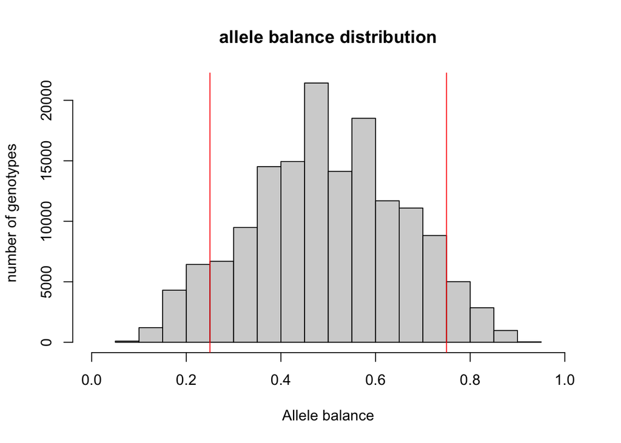

### max depth filter (super high depth loci are likely multiple loci stuck together into a single paralogous locus).

```r
#visualize and pick appropriate max depth cutoff
max_depth(vcfR)
```

```
## cutoff is not specified, exploratory visualization will be generated.
```

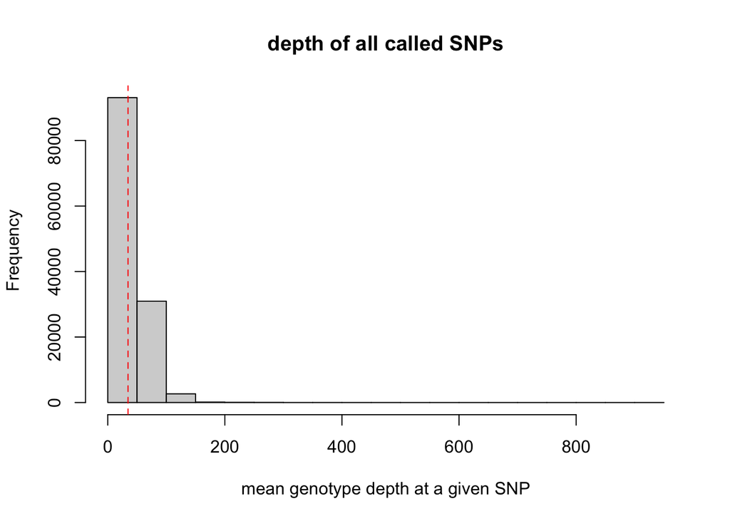

```
## dashed line indicates a mean depth across all SNPs of 34.6
```

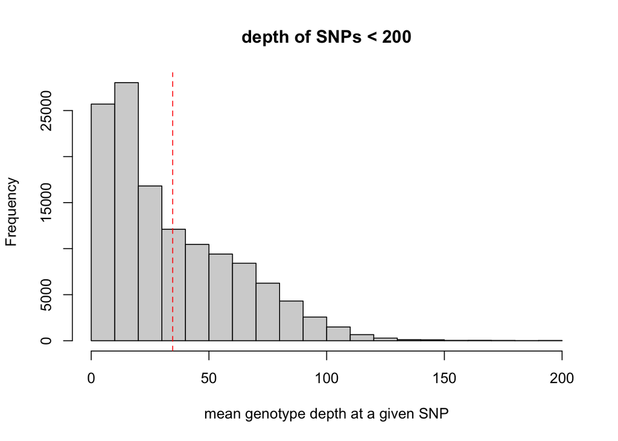

```r
#filter vcf by the max depth cutoff you chose
vcfR<-max_depth(vcfR, maxdepth = 100)
```

```
## maxdepth cutoff is specified, filtered vcfR object will be returned
```

```
## 2.21% of SNPs were above a mean depth of 100 and were removed from the vcf
```

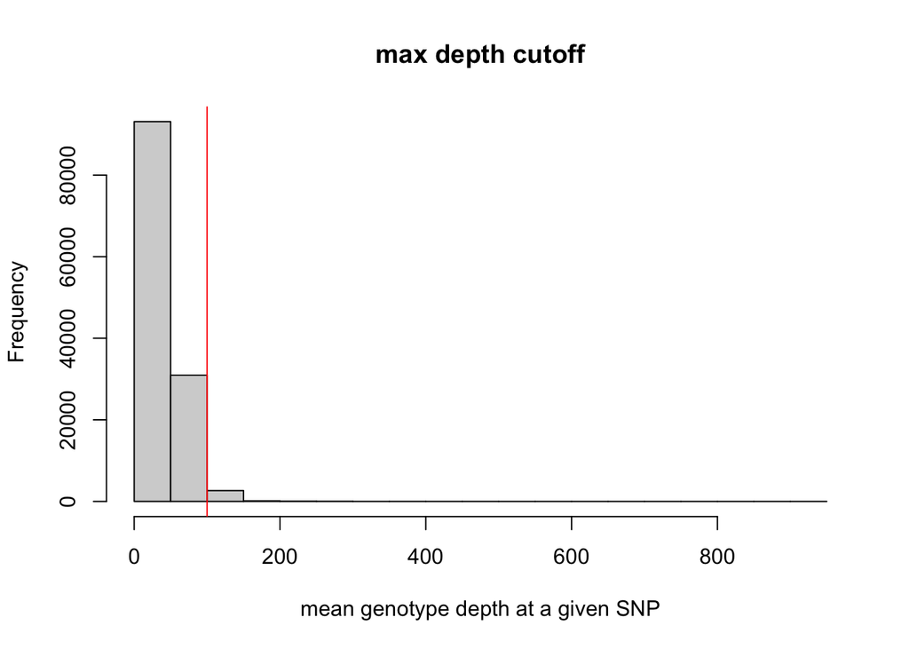

```r
#remove SNPs that have become invariant
vcfR<-min_mac(vcfR, min.mac = 1)
```

```
## 24.61% of SNPs fell below a minor allele count of 1 and were removed from the VCF
```

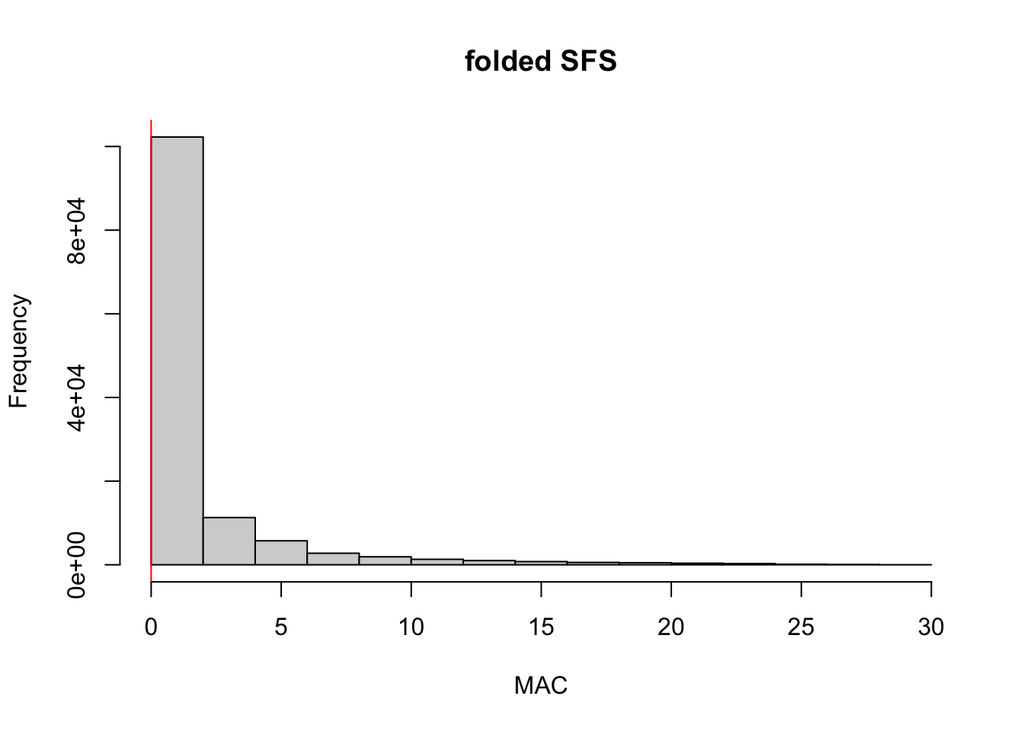

```r
#check vcfR to see how many SNPs we have left
vcfR
```

```
## ***** Object of Class vcfR *****
## 31 samples
## 42080 CHROMs
## 97,161 variants
## Object size: 172.2 Mb
## 33.97 percent missing data
## *****        *****         *****
```

## Step 2: visualize missing data by sample. Check out the visualizations and make decision on which samples to keep for downstream analysis.

```r
#run function to visualize samples
miss<-missing_by_sample(vcfR=vcfR)
```

```
## No popmap provided
```

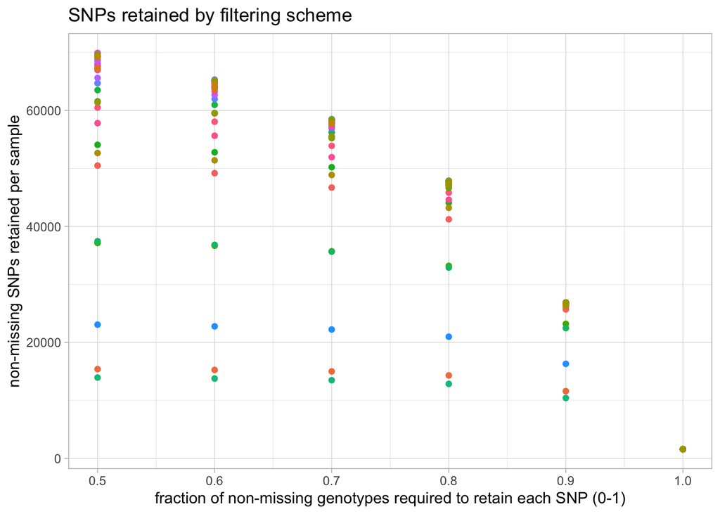

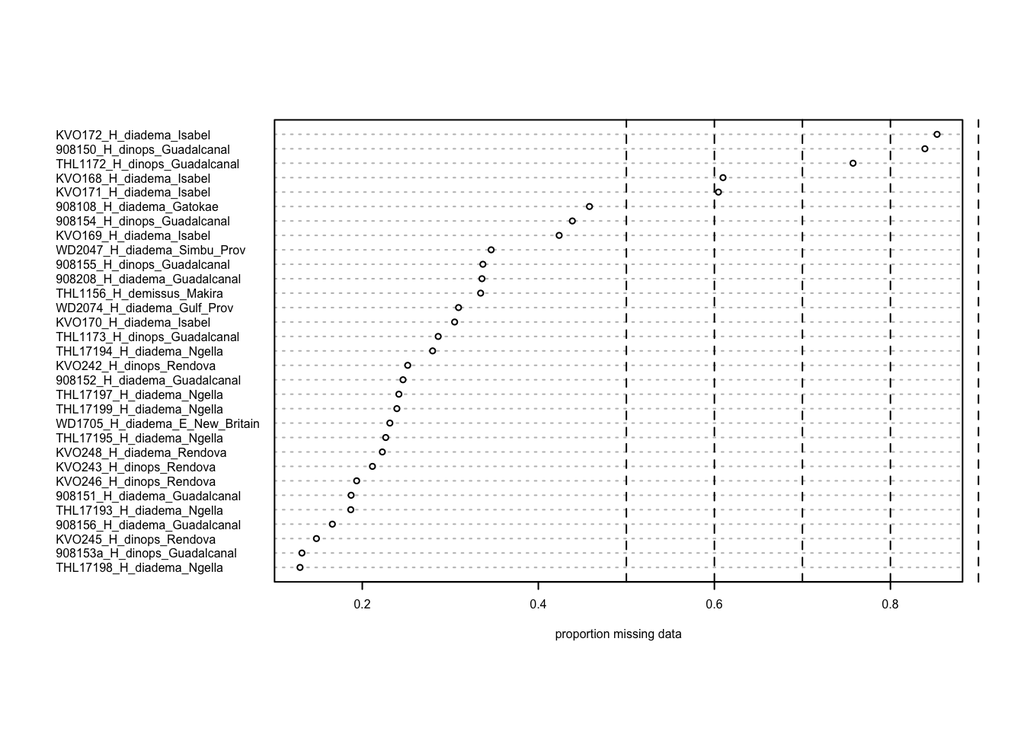

```r
#looks like 3 samples that just don't improve and will always be low
#run function to drop samples above the threshold we want from the vcf
vcfR<-missing_by_sample(vcfR=vcfR, cutoff = .7)
```

```
## 3 samples are above a 0.7 missing data cutoff, and were removed from VCF
```

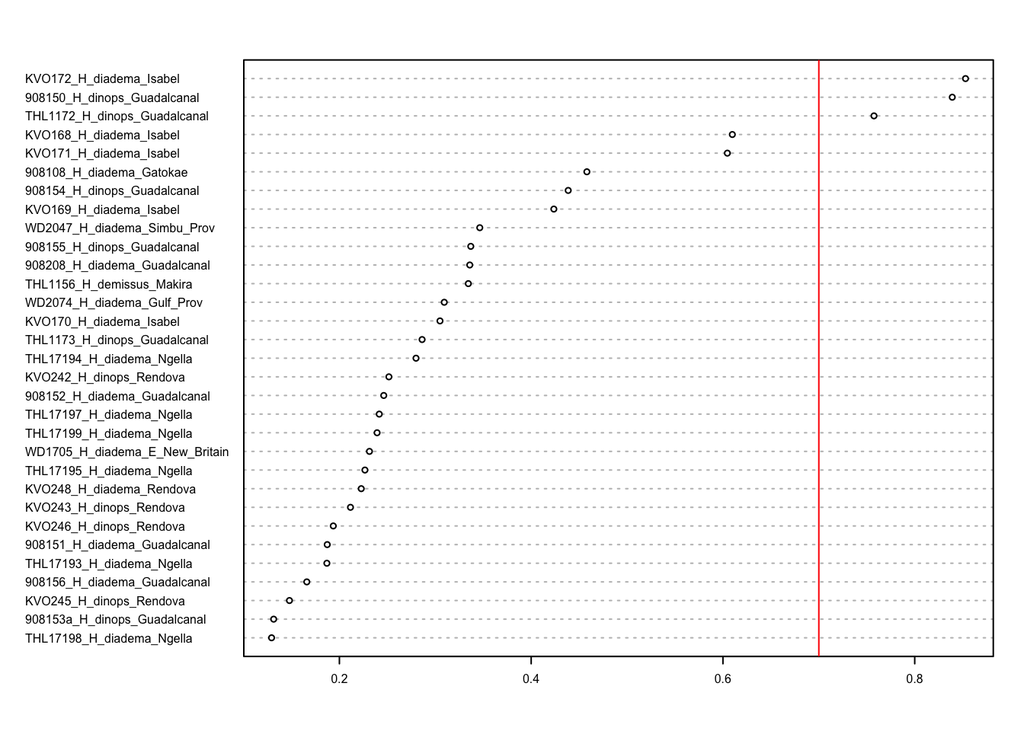

```r
#remove SNPs that became invariant
vcfR<-min_mac(vcfR, min.mac = 1)
```

```
## 0.37% of SNPs fell below a minor allele count of 1 and were removed from the VCF
```

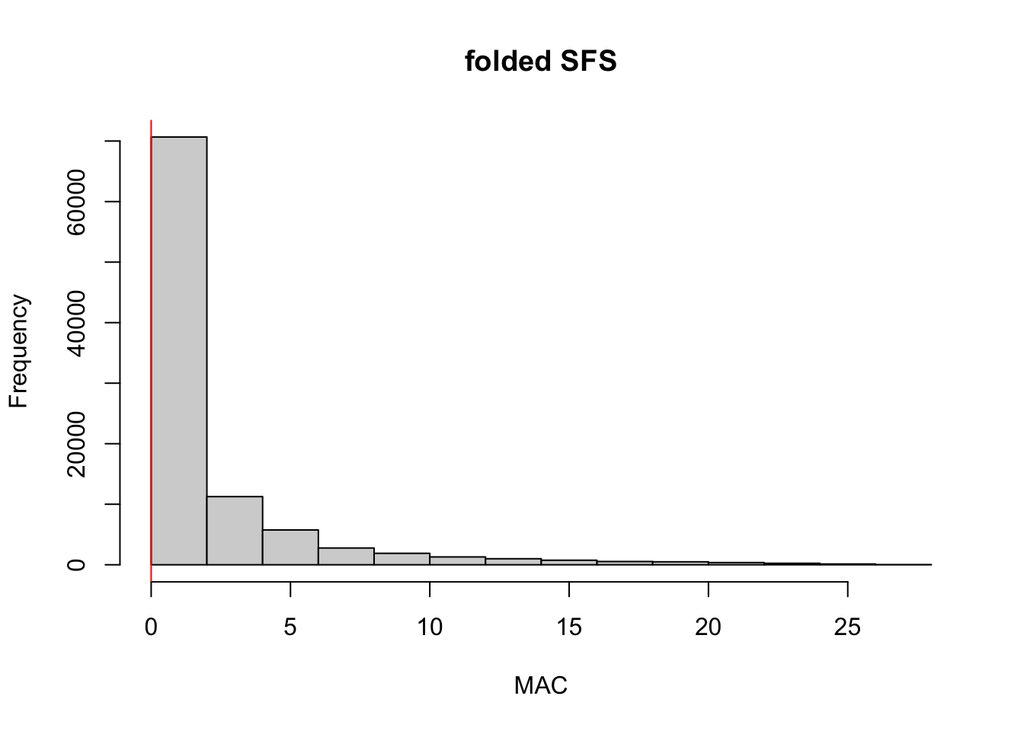

```r
#subset popmap to only include retained individuals
popmap<-popmap[popmap$id %in% colnames(vcfR@gt),]

#alternatively, you can drop individuals from vcfR manually using the following syntax, if a strict cutoff doesn't work for your dataset
#vcfR@gt <- vcfR@gt[,colnames(vcfR@gt) != "KVO248_H_dinops_Isabel"]
```

## Step 3: Set the arbitrary missing data cutoff

### We can visualize the effect that typical missing data cutoffs will have on both the number of SNPs retained and the total missing data in our entire dataset.

### We want to choose a cutoff that minimizes the overall missing data in the dataset, while maximizing the total number of loci retained.

```r
#visualize missing data by SNP and the effect of various cutoffs on the missingness of each sample
missing_by_snp(vcfR)
```

```
## cutoff is not specified, exploratory visualizations will be generated
```

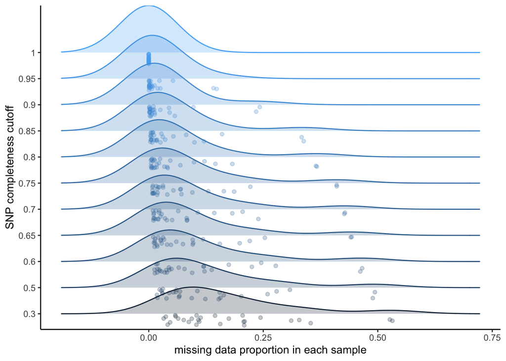

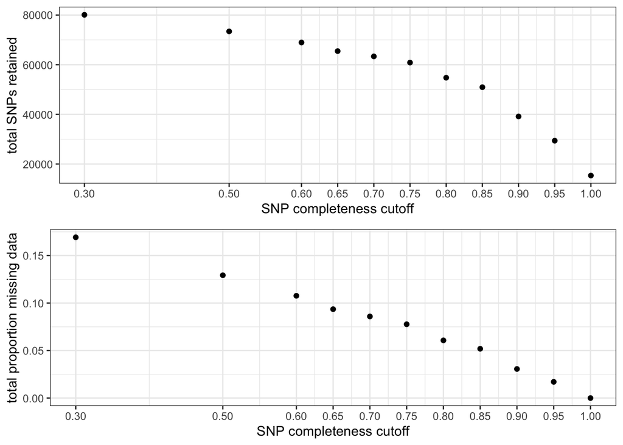

```
##    filt missingness snps.retained
## 1  0.30  0.16922453         80103
## 2  0.50  0.12928334         73424
## 3  0.60  0.10764528         68952
## 4  0.65  0.09353934         65482
## 5  0.70  0.08589591         63357
## 6  0.75  0.07768397         60856
## 7  0.80  0.06070255         54770
## 8  0.85  0.05185781         50947
## 9  0.90  0.03060286         39163
## 10 0.95  0.01704753         29401
## 11 1.00  0.00000000         15367
```

```r
#choose a value that retains an acceptable amount of missing data in each sample, and maximizes SNPs retained while minimizing overall missing data, and filter vcf
vcfR<-missing_by_snp(vcfR, cutoff = .9)
```

```
## cutoff is specified, filtered vcfR object will be returned
```

```
## 59.54% of SNPs fell below a completeness cutoff of 0.9 and were removed from the VCF
```

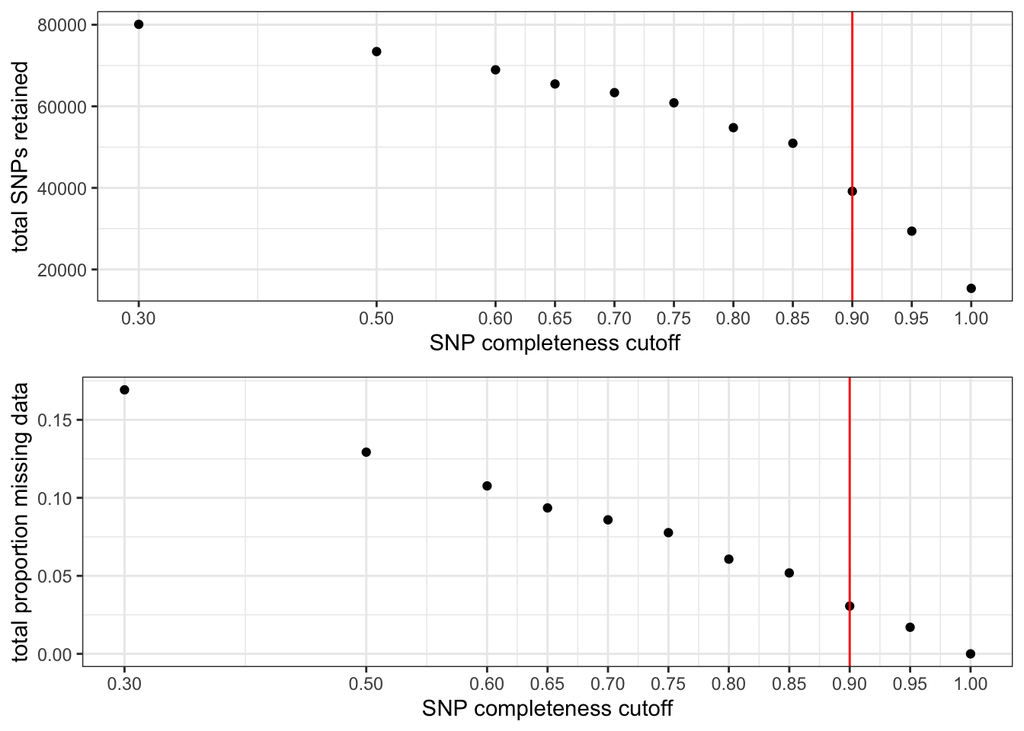

## check the effect of mac threshold on clustering

```
## 56.07% of SNPs fell below a minor allele count of 2 and were removed from the VCF
```

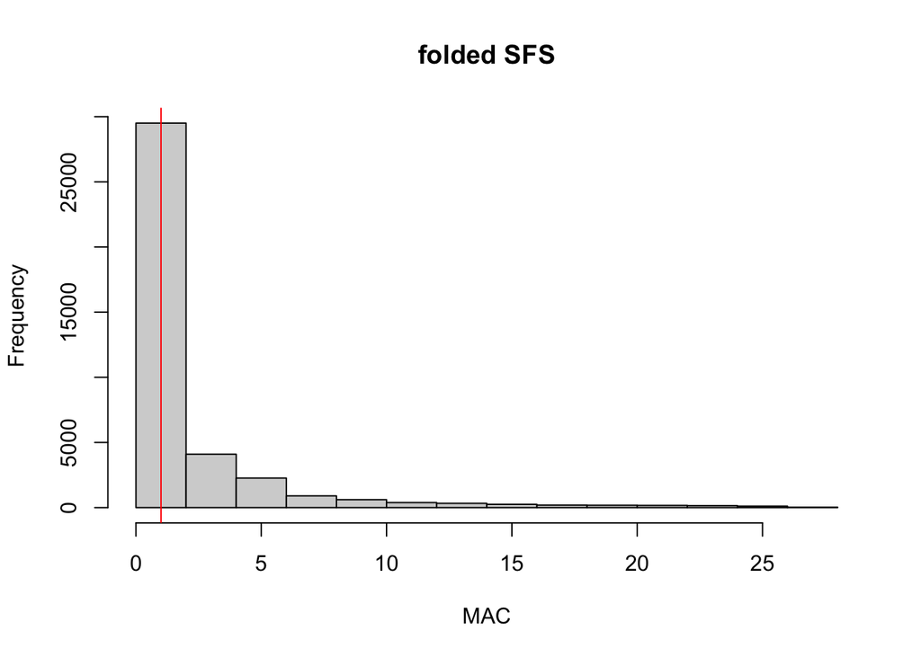

```r
#drop invariant sites plus singletons for plotting
vcf.filt<-min_mac(vcfR, min.mac = 2)
```

```r
#compare SNP counts
vcfR
```

```
## ***** Object of Class vcfR *****
## 28 samples
## 15612 CHROMs
## 39,163 variants
## Object size: 95 Mb
## 3.06 percent missing data
## *****        *****         *****
```

```r
vcf.filt
```

```
## ***** Object of Class vcfR *****
## 28 samples
## 10586 CHROMs
## 17,204 variants
## Object size: 43.2 Mb
## 3.285 percent missing data
## *****        *****         *****
```

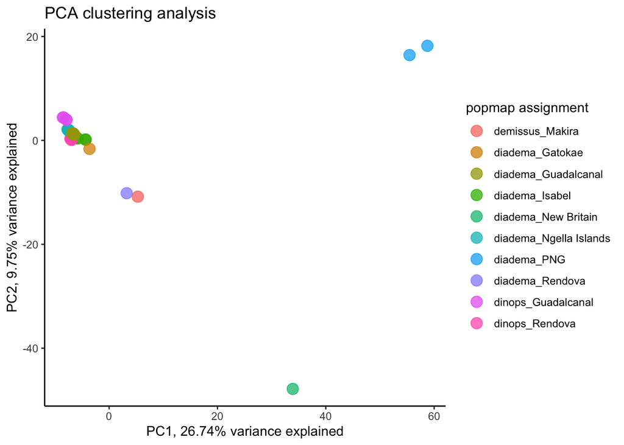

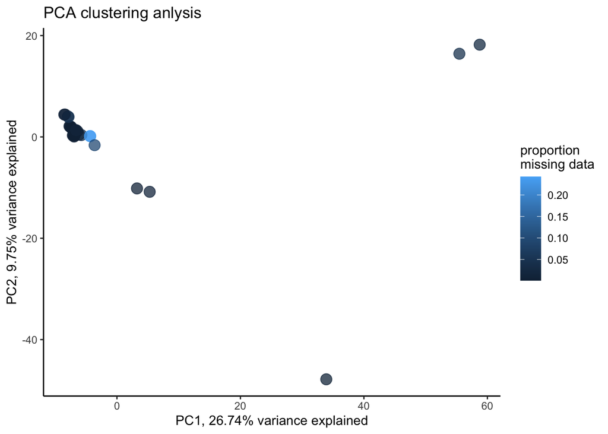

```
##                                      PC1          PC2         PC3         PC4
## KVO168_H_diadema_Isabel        -4.322769   0.16523800  -2.1247215  -0.1717140
## KVO169_H_diadema_Isabel        -5.762336   0.36906467  -2.7520041  -0.2590262
## KVO170_H_diadema_Isabel        -6.143734   0.44182377  -3.8747925  -0.5062781
## KVO171_H_diadema_Isabel        -4.378255   0.15744590  -2.3644947  -0.3142892
## KVO242_H_dinops_Rendova        -7.145868   0.29933735 -18.9937202 -10.2673143
## KVO243_H_dinops_Rendova        -6.945153   0.07644706 -19.2759031 -10.1938597
## KVO245_H_dinops_Rendova        -7.058468   0.31138770 -18.7700153 -10.3551306
## KVO246_H_dinops_Rendova        -6.901358   0.21746974 -18.6710316 -10.5789947
## KVO248_H_diadema_Rendova        3.243045 -10.16266855 -12.9326382  21.3050785
## THL1156_H_demissus_Makira       5.299973 -10.83234110  -6.1515588  20.2604961
## THL1173_H_dinops_Guadalcanal   -8.398138   4.41921968  12.4197627 -12.0065956
## THL17193_H_diadema_Ngella      -7.688488   2.11788542   5.5973404   6.9642674
## THL17194_H_diadema_Ngella      -7.459016   1.85689144   5.9453771   7.2964971
## THL17195_H_diadema_Ngella      -7.482989   1.92611635   5.3035233   7.1667924
## THL17197_H_diadema_Ngella      -7.423423   1.99926189   6.2943838   7.2673022
## THL17198_H_diadema_Ngella      -7.478536   1.94536756   5.7189598   7.3417300
## THL17199_H_diadema_Ngella      -7.597714   2.08044957   5.7679437   6.8573603
## WD1705_H_diadema_E_New_Britain 33.905373 -47.83926765   9.5553045 -11.8089320
## WD2047_H_diadema_Simbu_Prov    55.458749  16.41828534  -0.6612967   3.1656878
## WD2074_H_diadema_Gulf_Prov     58.750773  18.20718090  -0.6286177  -3.5859521
## 908108_H_diadema_Gatokae       -3.618215  -1.62824834  -4.4431550   5.0400985
## 908151_H_diadema_Guadalcanal   -6.812844   1.35631132   5.1545798   2.8933618
## 908152_H_diadema_Guadalcanal   -6.405276   1.12639135   4.8049122   3.3307447
## 908156_H_diadema_Guadalcanal   -6.706302   1.20933312   5.0168886   3.5706868
## 908208_H_diadema_Guadalcanal   -6.615993   1.34824473   4.8534106   2.6635294
## 908153a_H_dinops_Guadalcanal   -7.943474   4.04009066  11.8107449 -11.7912258
## 908154_H_dinops_Guadalcanal    -7.835812   3.96291918  11.1862553 -11.1182387
## 908155_H_dinops_Guadalcanal    -8.533755   4.41036296  12.2145627 -12.1660817
##                                        PC5        PC6          PC7          PC8
## KVO168_H_diadema_Isabel         -0.3122236   1.322801  -0.51782725  -0.98761115
## KVO169_H_diadema_Isabel         -0.5645116   1.993750  -0.75271098  -2.20363364
## KVO170_H_diadema_Isabel         -0.6393651   2.488394  -0.64535501  -2.18106345
## KVO171_H_diadema_Isabel         -0.3608630   1.288751  -0.41464833  -1.45134395
## KVO242_H_dinops_Rendova          0.1783427   2.923780  -1.56425532   1.34418396
## KVO243_H_dinops_Rendova          0.1558689   2.692952  -1.38964882   1.17692658
## KVO245_H_dinops_Rendova          0.1782550   2.813742  -1.65197749   1.36785135
## KVO246_H_dinops_Rendova          0.1591796   2.873668  -1.62868408   1.42766438
## KVO248_H_diadema_Rendova         3.1915201 -20.104951  28.23308806   2.38102828
## THL1156_H_demissus_Makira        3.2104687 -20.848255 -30.52044127   3.71111052
```

[output cut: 61 more lines]

```
## THL17195_H_diadema_Ngella       -2.01343983 diadema_Ngella Islands 0.0015320583
## THL17197_H_diadema_Ngella        2.47396498 diadema_Ngella Islands 0.0022725532
## THL17198_H_diadema_Ngella        1.33859013 diadema_Ngella Islands 0.0034981998
## THL17199_H_diadema_Ngella       -2.93755190 diadema_Ngella Islands 0.0023746904
## WD1705_H_diadema_E_New_Britain  -0.04969603    diadema_New Britain 0.0103413937
## WD2047_H_diadema_Simbu_Prov     -0.01125771            diadema_PNG 0.0443275541
## WD2074_H_diadema_Gulf_Prov      -0.01823888            diadema_PNG 0.0252278937
## 908108_H_diadema_Gatokae         0.62030629        diadema_Gatokae 0.0975921150
## 908151_H_diadema_Guadalcanal    -1.73353603    diadema_Guadalcanal 0.0017618671
## 908152_H_diadema_Guadalcanal    -5.38304703    diadema_Guadalcanal 0.0028853765
## 908156_H_diadema_Guadalcanal     3.32656595    diadema_Guadalcanal 0.0025789648
## 908208_H_diadema_Guadalcanal     2.82310646    diadema_Guadalcanal 0.0130224957
## 908153a_H_dinops_Guadalcanal    -0.43022276     dinops_Guadalcanal 0.0117713148
## 908154_H_dinops_Guadalcanal      0.47508155     dinops_Guadalcanal 0.0569415009
## 908155_H_dinops_Guadalcanal     -0.23465088     dinops_Guadalcanal 0.0080688405
```

```r
#assess the effect of MAC cutoff on clustering inferences
assess_missing_data_pca(vcfR, popmap = popmap, clustering = FALSE)
```

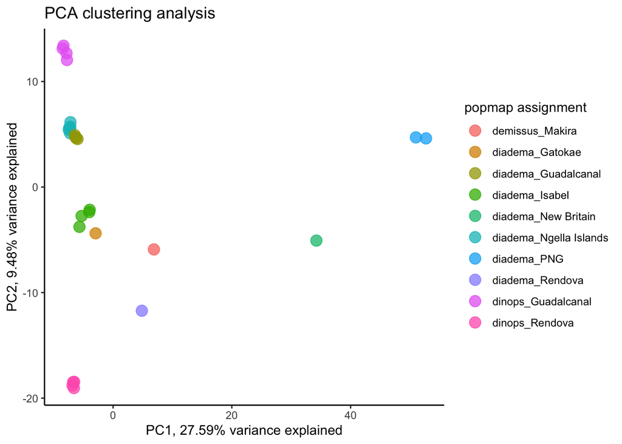

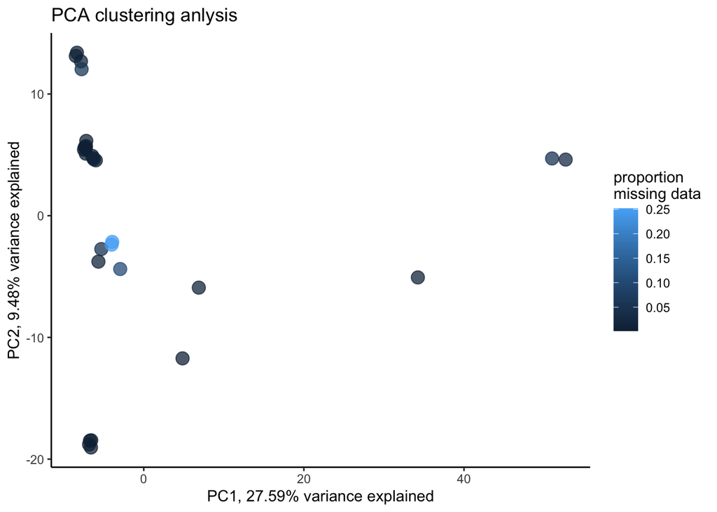

```
##                                      PC1        PC2          PC3         PC4
## KVO168_H_diadema_Isabel        -3.939099  -2.152821  -0.02355255   1.0846086
## KVO169_H_diadema_Isabel        -5.302861  -2.742261  -0.00835489   1.6722960
## KVO170_H_diadema_Isabel        -5.664493  -3.772521   0.25960387   2.1281426
## KVO171_H_diadema_Isabel        -4.004187  -2.374643   0.10378357   1.0379086
## KVO242_H_dinops_Rendova        -6.828277 -18.794554  10.23020336   2.2659686
## KVO243_H_dinops_Rendova        -6.595433 -19.042123  10.08095948   2.0036386
## KVO245_H_dinops_Rendova        -6.724548 -18.483560  10.24193341   2.1330207
## KVO246_H_dinops_Rendova        -6.557409 -18.451995  10.34166754   2.0420705
## KVO248_H_diadema_Rendova        4.844790 -11.720438 -15.15152114 -13.3540771
## THL1156_H_demissus_Makira       6.876050  -5.910016 -13.46919811 -12.8620042
## THL1173_H_dinops_Guadalcanal   -8.344976  13.390639  12.79907026 -12.3090518
## THL17193_H_diadema_Ngella      -7.462417   5.424875  -7.65406236   9.3870153
## THL17194_H_diadema_Ngella      -7.212504   5.714998  -8.10746306   9.2346620
## THL17195_H_diadema_Ngella      -7.232960   5.099645  -7.88814802   9.4404786
## THL17197_H_diadema_Ngella      -7.180437   6.145905  -7.95041150   8.9175361
## THL17198_H_diadema_Ngella      -7.240519   5.523400  -8.11053307   9.5074569
## THL17199_H_diadema_Ngella      -7.376344   5.624636  -7.60837228   9.2456064
## WD1705_H_diadema_E_New_Britain 34.236363  -5.071131 -17.08446349 -23.0783929
## WD2047_H_diadema_Simbu_Prov    50.997181   4.702554   9.60870030  10.5246563
## WD2074_H_diadema_Gulf_Prov     52.697277   4.610455   9.53935067  10.4134054
## 908108_H_diadema_Gatokae       -2.940582  -4.381264  -4.24924480  -0.2663192
## 908151_H_diadema_Guadalcanal   -6.425368   4.908380  -3.01133321   1.4486688
## 908152_H_diadema_Guadalcanal   -5.985423   4.549783  -3.43676169   1.5850529
## 908156_H_diadema_Guadalcanal   -6.307705   4.724902  -3.72325413   1.9575235
## 908208_H_diadema_Guadalcanal   -6.227296   4.635207  -2.78100517   1.4456066
## 908153a_H_dinops_Guadalcanal   -7.844895  12.683094  12.44576577 -12.2297550
## 908154_H_dinops_Guadalcanal    -7.765127  12.037512  11.77366254 -11.3006719
## 908155_H_dinops_Guadalcanal    -8.488802  13.121345  12.83297872 -12.0750510
##                                        PC5          PC6          PC7
## KVO168_H_diadema_Isabel          0.3783612  -0.70367097  0.978783858
## KVO169_H_diadema_Isabel          0.6040293  -1.06900140  2.125009930
## KVO170_H_diadema_Isabel          0.7127682  -0.87965940  2.103293526
## KVO171_H_diadema_Isabel          0.3698812  -0.63053490  1.423650727
## KVO242_H_dinops_Rendova          3.4564168  -0.39929278 -1.363742649
## KVO243_H_dinops_Rendova          3.2690639  -0.25945240 -1.181584205
## KVO245_H_dinops_Rendova          3.4840816  -0.48932867 -1.383480207
## KVO246_H_dinops_Rendova          3.7699011  -0.42259051 -1.424439660
## KVO248_H_diadema_Rendova       -25.7676766  22.09418632 -0.347560544
## THL1156_H_demissus_Makira      -15.6135243 -29.59562287 -8.532835853
```

[output cut: 90 more lines]

```
## THL17195_H_diadema_Ngella      0.001976285
## THL17197_H_diadema_Ngella      0.003313183
## THL17198_H_diadema_Ngella      0.003371309
## THL17199_H_diadema_Ngella      0.002906301
## WD1705_H_diadema_E_New_Britain 0.012380842
## WD2047_H_diadema_Simbu_Prov    0.051848407
## WD2074_H_diadema_Gulf_Prov     0.028946757
## 908108_H_diadema_Gatokae       0.102650546
## 908151_H_diadema_Guadalcanal   0.002208789
## 908152_H_diadema_Guadalcanal   0.003836317
## 908156_H_diadema_Guadalcanal   0.002731923
## 908208_H_diadema_Guadalcanal   0.015170890
## 908153a_H_dinops_Guadalcanal   0.012438968
## 908154_H_dinops_Guadalcanal    0.058823529
## 908155_H_dinops_Guadalcanal    0.009590793
```

```r
assess_missing_data_pca(vcf.filt, popmap = popmap, clustering = FALSE)
```

```r
#mac filter significantly improves our ability to discrimate between clusters, i.e., increases signal to noise ratio, so we will keep this one for downstream analyses
```

### plot quality heatmaps

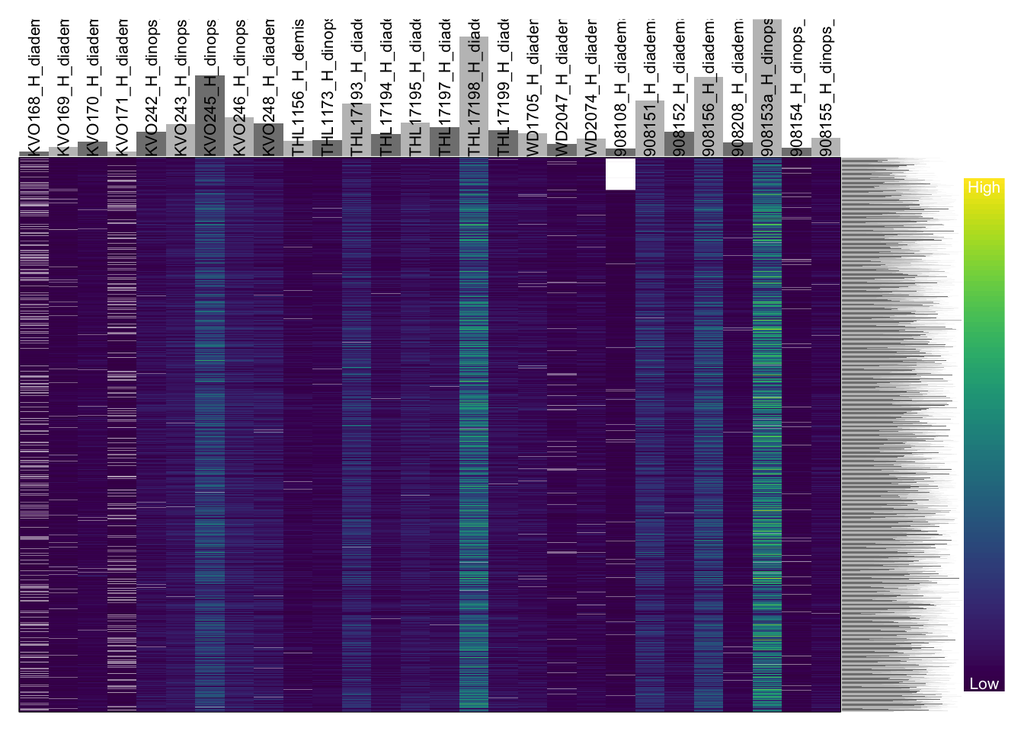

```r
#plot depth per snp and per sample
dp <- extract.gt(vcf.filt, element = "DP", as.numeric=TRUE)
heatmap.bp(dp, rlabels = FALSE)
```

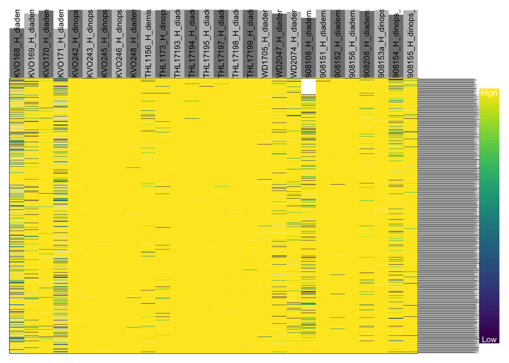

```r
#plot genotype quality per snp and per sample
gq <- extract.gt(vcf.filt, element = "GQ", as.numeric=TRUE)
heatmap.bp(gq, rlabels = FALSE)
```

### We can filter for linkage (one SNP per locus) and use the convenient function ‘write.vcf’ from vcfR to export our filtered vcf file for downstream analyses

```r
#final filetered vcf stats
vcf.filt
```

```
## ***** Object of Class vcfR *****
## 28 samples
## 10586 CHROMs
## 17,204 variants
## Object size: 43.2 Mb
## 3.285 percent missing data
## *****        *****         *****
```

```r
#write out the filtered vcf file
#write.vcf(vcf.filt, file = "~/Desktop/hipposideros/filtered.vcf.gz")

#filter to one SNP per locus to get an unlinked dataset
unlinked.vcf<-distance_thin(vcf.filt, min.distance = 10000)
```

```
## 10586 out of 17204 input SNPs were not located within 10000 base-pairs of another SNP and were retained despite filtering
```

```r
#final filetered, unlinked vcf stats
unlinked.vcf
```

```
## ***** Object of Class vcfR *****
## 28 samples
## 10586 CHROMs
## 10,586 variants
## Object size: 27 Mb
## 3.392 percent missing data
## *****        *****         *****
```

```r
#write out vcf file of unlinked SNPs
#write.vcf(unlinked.vcf, file = "~/Desktop/hipposideros/unlinked.filtered.vcf.gz")
```